# Homework 11

2026-02-16

## Instructions

Answer the following questions and complete the exercises in RMarkdown. Please embed all of your code and push your final work to your repository. Your final lab report should be organized, clean, and run free from errors. Remember, you must remove the `#` for the included code chunks to run. Be sure to add your name to the author header above. For any included plots, make sure they are clearly labeled. You are free to use any plot type that you feel best communicates the results of your analysis.

Make sure to use the formatting conventions of RMarkdown to make your report neat and clean!

## Load the libraries

```r
library(tidyverse)
library(janitor)
```

```r
options(scipen = 999)
```

## Data

For this homework, we are going to use the [Gapminder](https://www.gapminder.org/data/) data on population (pop), GDP per capita (gdp), and life expectancy (lex). These data were downloaded and compiled using the `gapminder_compile.Rmd` script in the data folder.

Let’s focus our attention on data from the past 100 years, between 1925 and 2025.

```r
gapminder <- read_csv("data/gapminder.csv") %>%
  clean_names() %>%
  filter(between(year, 1925, 2025))
```

1. Use the function(s) of your choice to get an idea of the overall structure of the data, including its dimensions, column names, classes, etc.

```r
summary(gapminder)
```

```
##    country               year           pop                  gdp
##  Length:19695       Min.   :1925   Min.   :       651   Min.   :   316
##  Class :character   1st Qu.:1950   1st Qu.:    741871   1st Qu.:  2124
##  Mode  :character   Median :1975   Median :   3915338   Median :  4661
##                     Mean   :1975   Mean   :  22712317   Mean   : 12054
##                     3rd Qu.:2000   3rd Qu.:  12044477   3rd Qu.: 13082
##                     Max.   :2025   Max.   :1463865525   Max.   :475911
##                                    NA's   :25           NA's   :202
##       lex
##  Min.   : 4.18
##  1st Qu.:48.13
##  Median :61.91
##  Mean   :59.17
##  3rd Qu.:70.89
##  Max.   :85.63
##  NA's   :357
```

```r
gapminder
```

```
## # A tibble: 19,695 × 5
##    country      year     pop   gdp   lex
##    <chr>       <dbl>   <dbl> <dbl> <dbl>
##  1 Afghanistan  1925 8748779 1114.  38.9
##  2 Afghanistan  1926 8289705 1128.  39.0
##  3 Afghanistan  1927 7854721 1142.  39.2
##  4 Afghanistan  1928 7442562 1157.  39.3
##  5 Afghanistan  1929 7121951 1171.  39.4
##  6 Afghanistan  1930 6888085 1186.  39.6
##  7 Afghanistan  1931 6736411 1201.  39.7
##  8 Afghanistan  1932 6662618 1216.  39.9
##  9 Afghanistan  1933 6662618 1231.  40.0
## 10 Afghanistan  1934 6662618 1247.  40.2
## # ℹ 19,685 more rows
```

2. How many countries are represented in this dataset?

```r
gapminder %>%
  summarize(country_num =n_distinct(country))
```

```
## # A tibble: 1 × 1
##   country_num
##         <int>
## 1         195
```

3. Which five countries have had the largest absolute population growth between 1925-2025? Show this as a table.

```r
 gapminder %>%
  select(pop, year, country) %>%
  filter(year %in% c(1925, 2025)) %>%
  pivot_wider(names_from = "year",
              values_from = "pop") %>%
  mutate(growth= `2025` - `1925`) %>%
  arrange(desc(growth)) %>%
  slice_head(n = 5)
```

```
## # A tibble: 5 × 4
##   country      `1925`     `2025`     growth
##   <chr>         <dbl>      <dbl>      <dbl>
## 1 India     304406019 1463865525 1159459506
## 2 China     473741473 1416096094  942354621
## 3 Indonesia  49685263  285721236  236035973
## 4 Pakistan   22624808  255219554  232594746
## 5 USA       116193761  347275807  231082046
```

4. Make a plot that shows population growth over time for the top country you found in question #3.

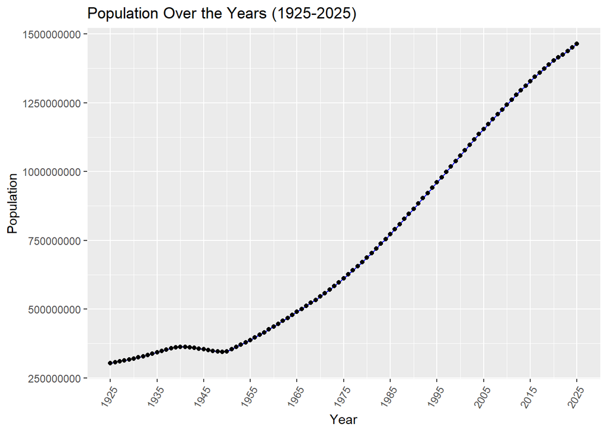

```r
gapminder %>%
  select(pop, year, country) %>%
  filter(year>=1925 & year<=2025, country == "India") %>%
  pivot_wider(names_from = "year",
              values_from = "pop") %>%
  mutate(growth= `2025` - `1925`) %>%
  pivot_longer(-c(country,growth),
               names_to = "year",
               values_to = "pop") %>%
  mutate(year = as.numeric(year)) %>%
   ggplot(aes(x=year ,y= pop))+
geom_line(color="blue")+
  geom_point()+
  scale_x_continuous(breaks = seq(1925,2025,by=10))+
  theme(axis.text.x= element_text(angle = 60, hjust= 1))+
  labs(title = "Population Over the Years (1925-2025)",
       x="Year",
       y="Population")
```

5. Has global life expectancy changed between 1925 and 2025? Show the min, median, mean, and max for all countries (combined) in the dataset.

```r
gapminder %>%
  select(year, country, lex) %>%
  filter(year %in% c(1925, 2025)) %>%
  group_by(country) %>%
mutate(lex_avg= mean(lex,  na.rm = T),
          lex_min=min(lex, na.rm = T),
          lex_max=max(lex,  na.rm = T),
          lex_med=median(lex,  na.rm = T),)
```

```
## # A tibble: 390 × 7
## # Groups:   country [195]
##     year country       lex lex_avg lex_min lex_max lex_med
##    <dbl> <chr>       <dbl>   <dbl>   <dbl>   <dbl>   <dbl>
##  1  1925 Afghanistan  38.9    52.0    38.9    65.1    52.0
##  2  2025 Afghanistan  65.1    52.0    38.9    65.1    52.0
##  3  1925 Angola       36.8    51.5    36.8    66.3    51.5
##  4  2025 Angola       66.3    51.5    36.8    66.3    51.5
##  5  1925 Albania      34.3    57.0    34.3    79.7    57.0
##  6  2025 Albania      79.7    57.0    34.3    79.7    57.0
##  7  1925 Andorra      NA      83.2    83.2    83.2    83.2
##  8  2025 Andorra      83.2    83.2    83.2    83.2    83.2
##  9  1925 UAE          40.3    57.6    40.3    74.9    57.6
## 10  2025 UAE          74.9    57.6    40.3    74.9    57.6
## # ℹ 380 more rows
```

6. Make a plot that shows the distribution of life expectancy for all countries in 1925 and 2025 (try using `geom_density`). What do you notice about the shift in life expectancy over time?

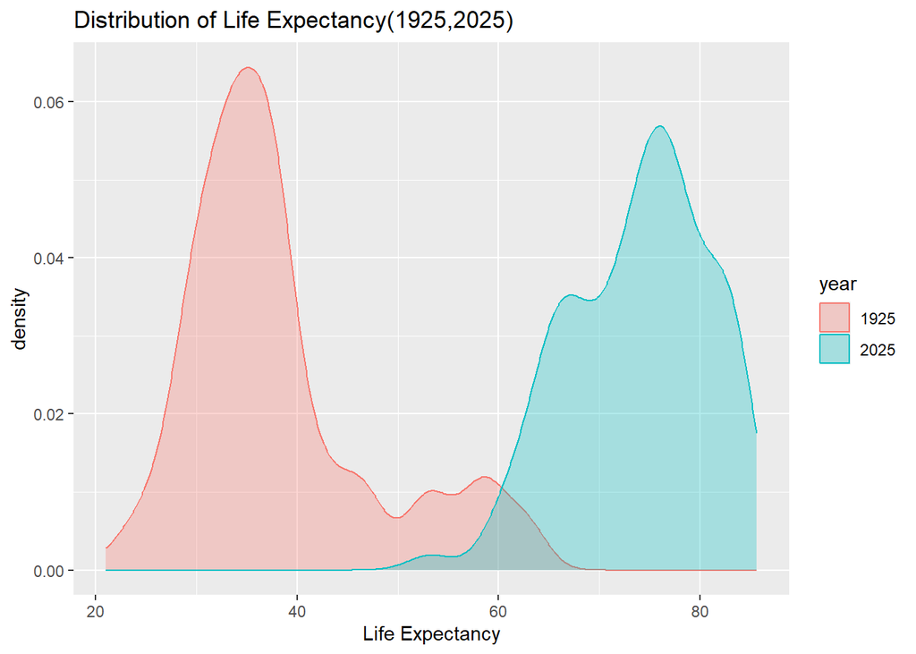

```r
gapminder %>%
    filter(year %in% c(1925, 2025)) %>% #pull out the years
  mutate(year=factor(year)) %>%
  ggplot(aes(x=lex,color=year, fill=year ))+
  geom_density(alpha=0.3)+
  labs(title = "Distribution of Life Expectancy(1925,2025)",
       x= "Life Expectancy",
       Y= NULL)
```

7. We are interested in the relationship between per capita GDP and life expectancy; i.e. does having more money help you live longer in 2025? Show this as a plot. (Suggestion! Remove Monaco as an extreme outlier.)

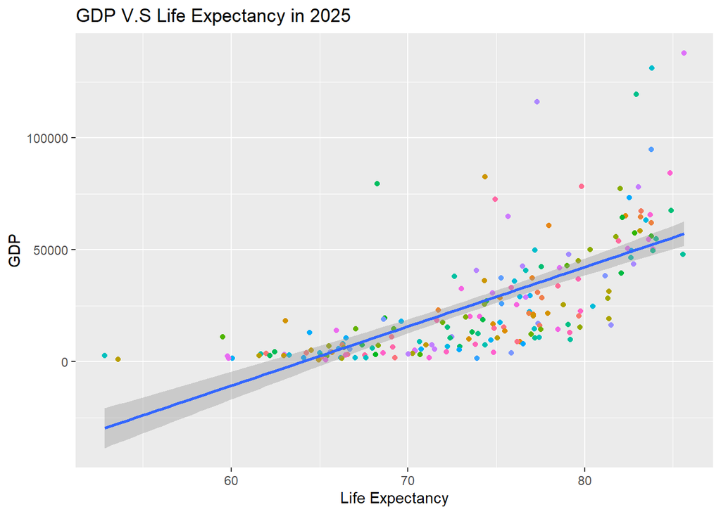

```r
 gapminder %>%
  select(gdp, lex, year, country) %>%
  filter(year==2025) %>%
  arrange(desc(gdp)) %>%
  slice(-1) %>%
  ggplot(aes(y=gdp, x= lex))+
  geom_point(aes(color=country))+
  theme(legend.position = "none")+
  geom_smooth(method = lm, se=T)+
  labs(title = "GDP V.S Life Expectancy in 2025",
       x= "Life Expectancy",
       y= "GDP")
```

8. Which five countries have had the highest absolute GDP per capita growth over the past 50 years? Show this as a table. (Suggestion! Remove Monaco as an extreme outlier.)

```r
gapminder %>%
  select(gdp, country, year) %>%
  filter(year>=1975 & year<=2025,
         country!= "Monaco") %>%
  pivot_wider(names_from = "year",
              values_from = "gdp") %>%
  mutate(growth_gdp= `2025`-`1975`) %>%
  arrange(desc(growth_gdp)) %>%
  slice_head(n=5)
```

```
## # A tibble: 5 × 53
##   country  `1975` `1976` `1977` `1978` `1979` `1980` `1981` `1982` `1983` `1984`
##   <chr>     <dbl>  <dbl>  <dbl>  <dbl>  <dbl>  <dbl>  <dbl>  <dbl>  <dbl>  <dbl>
## 1 Singapo… 12896. 13677. 14475. 15482. 16734. 18149. 20193. 21480. 23608. 25832.
## 2 Ireland  14336. 14267. 15172. 15992. 16194. 16463. 17589. 18344. 18542. 19508.
## 3 Luxembo… 30950. 31560. 31932. 33122. 33787. 33966. 36043. 37564. 39452. 42565.
## 4 Guyana    5071.  5128.  4938.  4797.  4666.  4717.  5002.  4634.  4300.  4394.
## 5 Norway   25513. 26858. 27853. 28754. 29905. 31198. 33192. 34381. 36492. 39527.
## # ℹ 42 more variables: `1985` <dbl>, `1986` <dbl>, `1987` <dbl>, `1988` <dbl>,
## #   `1989` <dbl>, `1990` <dbl>, `1991` <dbl>, `1992` <dbl>, `1993` <dbl>,
## #   `1994` <dbl>, `1995` <dbl>, `1996` <dbl>, `1997` <dbl>, `1998` <dbl>,
## #   `1999` <dbl>, `2000` <dbl>, `2001` <dbl>, `2002` <dbl>, `2003` <dbl>,
## #   `2004` <dbl>, `2005` <dbl>, `2006` <dbl>, `2007` <dbl>, `2008` <dbl>,
## #   `2009` <dbl>, `2010` <dbl>, `2011` <dbl>, `2012` <dbl>, `2013` <dbl>,
## #   `2014` <dbl>, `2015` <dbl>, `2016` <dbl>, `2017` <dbl>, `2018` <dbl>, …
```

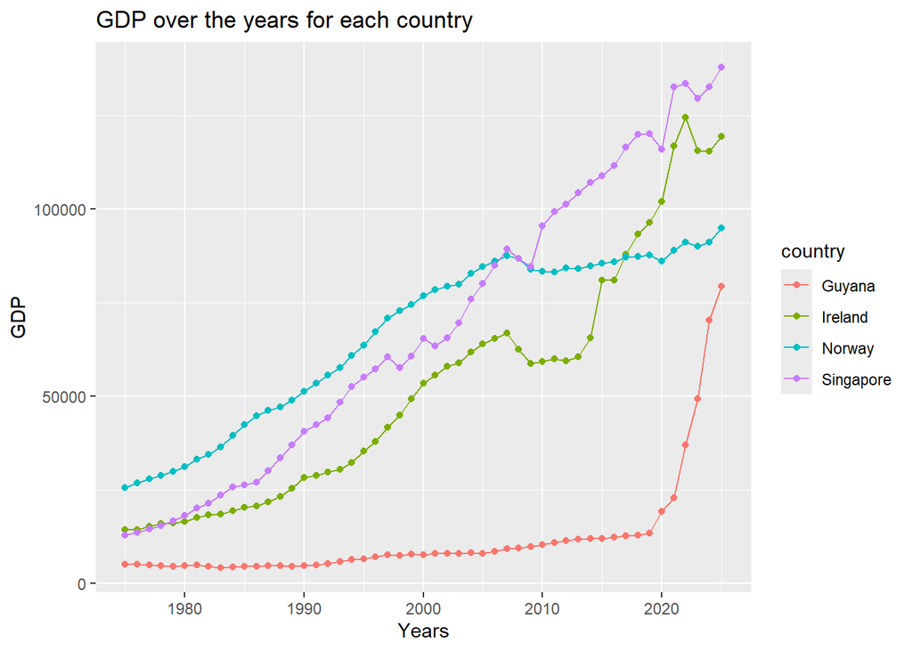

```r
gapminder %>%
  filter( country== "Singapore"|
         country== "Ireland"|
         country== "Luxembourge"|
         country== "Guyana"|
         country=="Norway",
         year>=1975 & year<=2025) %>%
  ggplot(aes(x=year, y= gdp, colour= country))+
  geom_line()+
  geom_point()+
  labs(title = "GDP over the years for each country",
       x="Years",
       y= "GDP")
```

10. Do one analysis of your choice that includes a table and plot as outputs.

```r
gapminder %>%
  select(country, year, pop) %>%
  filter(year>=2000 & year<=2025,
         country!= "Monaco") %>%
  pivot_wider(names_from = "year",
              values_from = "pop") %>%
  mutate(growth_pop= `2025`-`2000`) %>%
  arrange(desc(growth_pop)) %>%
  slice_tail(n=5)
```

```
## # A tibble: 5 × 28
##   country `2000`  `2001`  `2002`  `2003`  `2004`  `2005`  `2006`  `2007`  `2008`
##   <chr>    <dbl>   <dbl>   <dbl>   <dbl>   <dbl>   <dbl>   <dbl>   <dbl>   <dbl>
## 1 Russia  1.47e8  1.46e8  1.46e8  1.46e8  1.45e8  1.45e8  1.44e8  1.44e8  1.44e8
## 2 Romania 2.20e7  2.19e7  2.18e7  2.16e7  2.14e7  2.12e7  2.10e7  2.09e7  2.07e7
## 3 Japan   1.27e8  1.27e8  1.27e8  1.28e8  1.28e8  1.28e8  1.28e8  1.28e8  1.28e8
## 4 Ukraine 4.96e7  4.91e7  4.87e7  4.83e7  4.80e7  4.76e7  4.73e7  4.71e7  4.68e7
## 5 Holy S… 7.79e2 NA      NA      NA      NA      NA      NA      NA      NA
## # ℹ 18 more variables: `2009` <dbl>, `2010` <dbl>, `2011` <dbl>, `2012` <dbl>,
## #   `2013` <dbl>, `2014` <dbl>, `2015` <dbl>, `2016` <dbl>, `2017` <dbl>,
## #   `2018` <dbl>, `2019` <dbl>, `2020` <dbl>, `2021` <dbl>, `2022` <dbl>,
## #   `2023` <dbl>, `2024` <dbl>, `2025` <dbl>, growth_pop <dbl>
```

```
## `geom_line()`: Each group consists of only one observation.
## ℹ Do you need to adjust the group aesthetic?
```

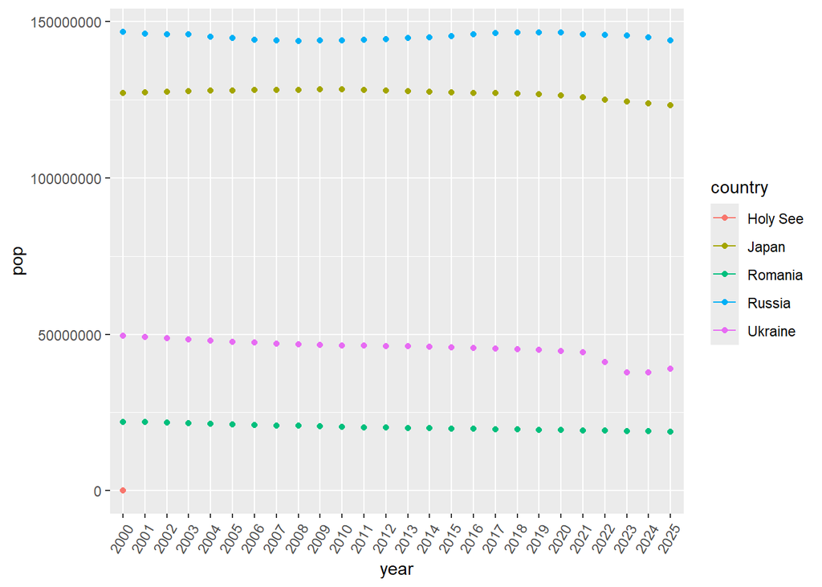

```r
gapminder %>%
   select(country, year, pop) %>%
  filter(year>=2000 & year<=2025,
         country!= "Monaco") %>%
  pivot_wider(names_from = "year",
              values_from = "pop") %>%
  mutate(growth_pop= `2025`-`2000`) %>%
  arrange(desc(growth_pop)) %>%
  slice_tail(n=5) %>%
  pivot_longer(-c(growth_pop, country),
               names_to = "year",
               values_to = "pop") %>%
  ggplot(aes(x=year, y=pop, colour= country))+
geom_line()+
  geom_point()+
  theme(axis.text.x= element_text(angle = 60, hjust= 1))
```

## Knit and Upload

Please knit your work as an .html file and upload to Canvas. Homework is due before the start of the next lab. No late work is accepted. Make sure to use the formatting conventions of RMarkdown to make your report neat and clean!